# ML2 Team 1 Presentation

## Linear Model Selection and Regularization

### Introduction

In this team presentation, you will have the chance to learn more about ridge and lasso regression and their implications on model selection. You will also have the chance to look at PCR and PLS models and their implications. The former concepts will be explored in two seperate labs, followed by a guided exercise from An Introduction to Statistical Learning.

Load `glmnet` and `ISLR` library

```r
library(glmnet)
library(ISLR)
data("Hitters")
```

Objectives: What parameters or features impact the salaries of major league baseball players?

The Data: Real Data Set- Major League Baseball Data from the 1986 and 1987 seasons [322x20]

Dims: AtBat, Hits, Home Runs, Runs, Runs Batted in, Walks, Years (Player has been in Majors) Career At Bats, Career Hits, Career Home Runs, Career Runs, Career Runs Batted in Career Walks, League (American or National), Division (East or West), Put Outs, Assists, Errors , Salary, and New League (Player’s 1987 League)

From the ISLR Library

Other notes: Some Null values that would need to be omitted, no transformations needed.  
More details can be found by using summary(Hitters) or str(Hitters)

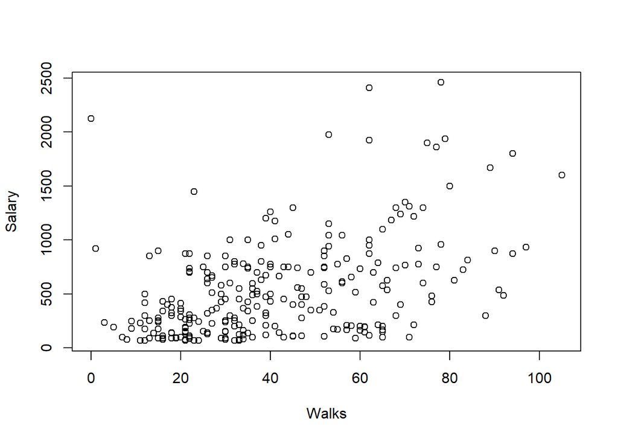

```r
sum(is.na(Hitters)) #59 N/A Values
[1] 59
HitData<-complete.cases(Hitters) # Figure out complete cases
HitData<-Hitters[HitData,] #Subset Complete cases
head(HitData)
                  AtBat Hits HmRun Runs RBI Walks Years CAtBat CHits CHmRun
-Alan Ashby         315   81     7   24  38    39    14   3449   835     69
-Alvin Davis        479  130    18   66  72    76     3   1624   457     63
-Andre Dawson       496  141    20   65  78    37    11   5628  1575    225
-Andres Galarraga   321   87    10   39  42    30     2    396   101     12
-Alfredo Griffin    594  169     4   74  51    35    11   4408  1133     19
-Al Newman          185   37     1   23   8    21     2    214    42      1
                  CRuns CRBI CWalks League Division PutOuts Assists Errors
-Alan Ashby         321  414    375      N        W     632      43     10
-Alvin Davis        224  266    263      A        W     880      82     14
-Andre Dawson       828  838    354      N        E     200      11      3
-Andres Galarraga    48   46     33      N        E     805      40      4
-Alfredo Griffin    501  336    194      A        W     282     421     25
-Al Newman           30    9     24      N        E      76     127      7
                  Salary NewLeague
-Alan Ashby        475.0         N
-Alvin Davis       480.0         A
-Andre Dawson      500.0         N
-Andres Galarraga   91.5         N
-Alfredo Griffin   750.0         A
-Al Newman          70.0         A
#summary(HitData)
str(HitData) # 19 Predictors - 3 are 2 level so ~19 to start
'data.frame':   263 obs. of  20 variables:
 $ AtBat    : int  315 479 496 321 594 185 298 323 401 574 ...
 $ Hits     : int  81 130 141 87 169 37 73 81 92 159 ...
 $ HmRun    : int  7 18 20 10 4 1 0 6 17 21 ...
 $ Runs     : int  24 66 65 39 74 23 24 26 49 107 ...
 $ RBI      : int  38 72 78 42 51 8 24 32 66 75 ...
 $ Walks    : int  39 76 37 30 35 21 7 8 65 59 ...
 $ Years    : int  14 3 11 2 11 2 3 2 13 10 ...
 $ CAtBat   : int  3449 1624 5628 396 4408 214 509 341 5206 4631 ...
 $ CHits    : int  835 457 1575 101 1133 42 108 86 1332 1300 ...
 $ CHmRun   : int  69 63 225 12 19 1 0 6 253 90 ...
 $ CRuns    : int  321 224 828 48 501 30 41 32 784 702 ...
 $ CRBI     : int  414 266 838 46 336 9 37 34 890 504 ...
 $ CWalks   : int  375 263 354 33 194 24 12 8 866 488 ...
 $ League   : Factor w/ 2 levels "A","N": 2 1 2 2 1 2 1 2 1 1 ...
 $ Division : Factor w/ 2 levels "E","W": 2 2 1 1 2 1 2 2 1 1 ...
 $ PutOuts  : int  632 880 200 805 282 76 121 143 0 238 ...
 $ Assists  : int  43 82 11 40 421 127 283 290 0 445 ...
 $ Errors   : int  10 14 3 4 25 7 9 19 0 22 ...
 $ Salary   : num  475 480 500 91.5 750 ...
 $ NewLeague: Factor w/ 2 levels "A","N": 2 1 2 2 1 1 1 2 1 1 ...
plot(Salary~Walks, data=Hitters)
```

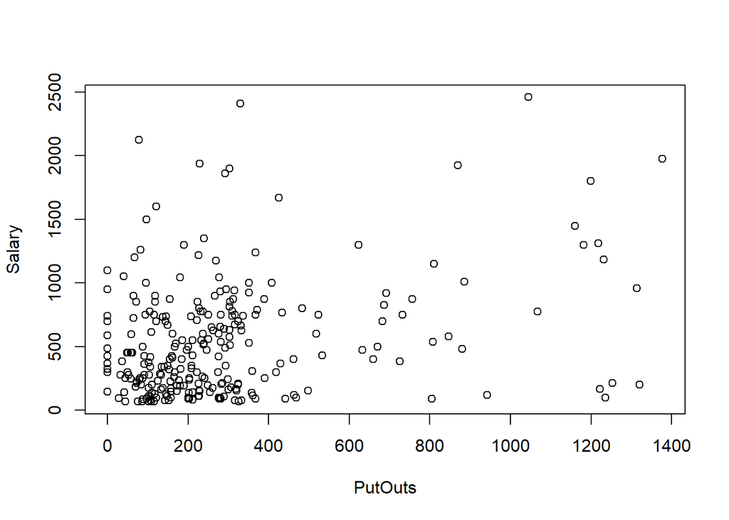

```r
plot(Salary~PutOuts, data=Hitters)
```

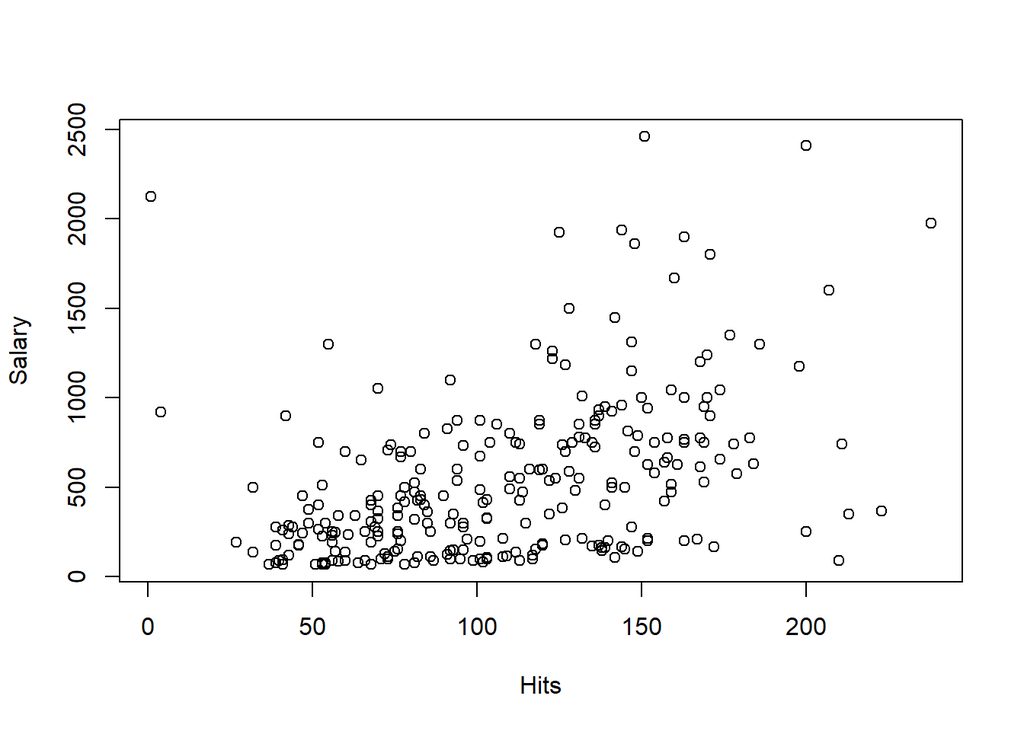

```r
plot(Salary~Hits, data=Hitters)
```

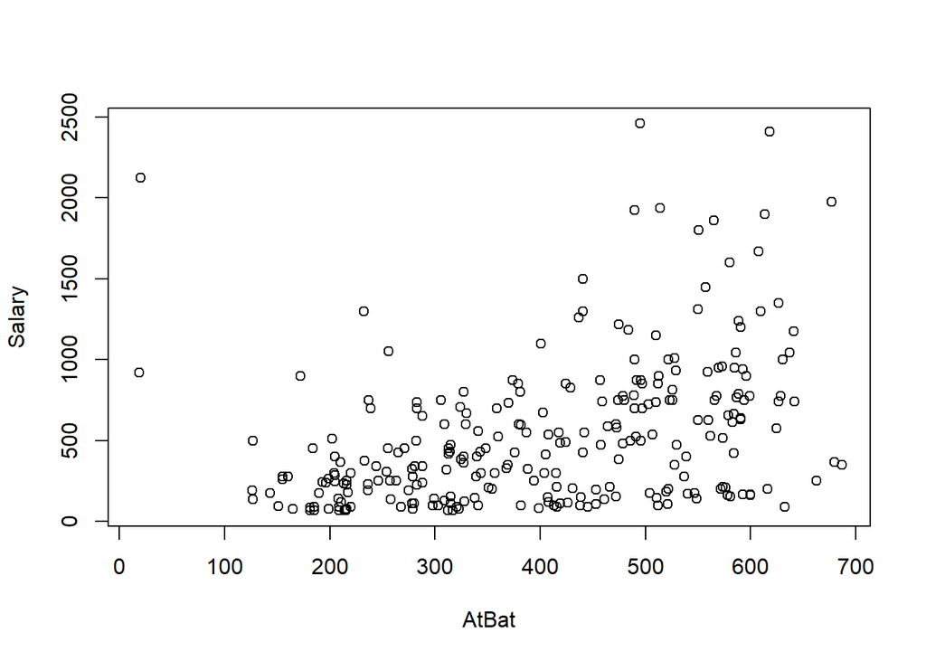

```r
plot(Salary~AtBat, data=Hitters)
```

We can also look at Multicollinearity using just a model using all factors and the lm() function and the vif() function from the car package.

### Ridge

**Create a Model**

Lets start by looking up what the model.matrix function does.

```r
#?model.matrix
```

model.matrix creates a design (or model) matrix, e.g., by expanding factors to a set of dummy variables (depending on the contrasts) and expanding interactions similarly.

Using this function,we can set up our “x” using the matrix and “y” values using the Salary column from the Hitters data

```r
x=model.matrix(Salary~.,HitData)[,-1]
y=HitData$Salary
```

**Create the model object**

We now will be using the glm package and glmnet() function to run the ridge regression. The glmnet() function uses a paramter “alpha” setting this to 0 will denote a **Ridge** regression while a 1 will denote a **Lasso**.

In this example we wil also be populating a **grid** of “lambda” values that control the penalty term which is a factor of the coefficients (l2)

Ridge Regression (alpha= (0=Ridge or 1=Lasso))

```r
grid=10^seq(10,-2,length=100)
ridge.mod=glmnet(x,y,alpha = 0,lambda = grid)
COEF<-coef(ridge.mod)
dim(COEF)
[1]  20 100
```

We can see we have 20 coefficients and 100 potential lamda values

*Exploring Lamda values*

We can explore the impact lamda and the penalty term have on the loss function by looiking at different potential values of lambda. Let’s look at the 50th element.

**Large Lambda**

```r
ridge.mod$lambda[50]
[1] 11497.57
coef(ridge.mod)[,50]
  (Intercept)         AtBat          Hits         HmRun          Runs
407.356050200   0.036957182   0.138180344   0.524629976   0.230701523
          RBI         Walks         Years        CAtBat         CHits
  0.239841459   0.289618741   1.107702929   0.003131815   0.011653637
       CHmRun         CRuns          CRBI        CWalks       LeagueN
  0.087545670   0.023379882   0.024138320   0.025015421   0.085028114
    DivisionW       PutOuts       Assists        Errors    NewLeagueN
 -6.215440973   0.016482577   0.002612988  -0.020502690   0.301433531
sqrt(sum(coef(ridge.mod)[-1,50]^2))# Find the L2 value
[1] 6.360612
```

The L2 value is much smaller showing that the coefficients for the factors have been shrunk

We can also look at the impact of a small lambda value and what that means for the beta coefficients

**Small Lambda**

```r
ridge.mod$lambda[60]
[1] 705.4802
coef(ridge.mod)[,60]
 (Intercept)        AtBat         Hits        HmRun         Runs          RBI
 54.32519950   0.11211115   0.65622409   1.17980910   0.93769713   0.84718546
       Walks        Years       CAtBat        CHits       CHmRun        CRuns
  1.31987948   2.59640425   0.01083413   0.04674557   0.33777318   0.09355528
        CRBI       CWalks      LeagueN    DivisionW      PutOuts      Assists
  0.09780402   0.07189612  13.68370191 -54.65877750   0.11852289   0.01606037
      Errors   NewLeagueN
 -0.70358655   8.61181213
sqrt(sum(coef(ridge.mod)[-1,60]^2)) # Find the L2 value
[1] 57.11001
```

The L2 value here is higher suggesting the coefficients for the factors are larger than they where for the larger lambda.

This makes logical sense as the value of lambda determines the magnitude of the L2 penalty term relative to the value of the loss function as a whole.

*Predicting with a lambda value*

We can also predict for a new given value of lambda by using the “s=” argument

```r
predict(ridge.mod,s=50,type = "coefficients")[1:20,]
  (Intercept)         AtBat          Hits         HmRun          Runs
 4.876610e+01 -3.580999e-01  1.969359e+00 -1.278248e+00  1.145892e+00
          RBI         Walks         Years        CAtBat         CHits
 8.038292e-01  2.716186e+00 -6.218319e+00  5.447837e-03  1.064895e-01
       CHmRun         CRuns          CRBI        CWalks       LeagueN
 6.244860e-01  2.214985e-01  2.186914e-01 -1.500245e-01  4.592589e+01
    DivisionW       PutOuts       Assists        Errors    NewLeagueN
-1.182011e+02  2.502322e-01  1.215665e-01 -3.278600e+00 -9.496680e+00
```

**Create Train & Test Data sets**

The next step involves creating test and training data sets. The book example is coded here, however the carat package could be used with the create data partition function and restructuring our “y” and “x” values to pass to the glmnet() function.

```r
set.seed(1)
train<-sample(1:nrow(x),nrow(x)/2)
test=(-train)
y.test=y[test]
```

We can now try a model using the training set with lambda value of 4. We then use the test data to get our MSE value to compare across models

```r
ridge.mod<-glmnet(x[train,],y[train],alpha = 0,lambda = grid, thresh=1e-12)
ridge.pred<-predict(ridge.mod,s=4,newx=x[test,])
mean((ridge.pred-y.test)^2)
[1] 142199.2
```

Using a lambda of 4, we get an MSE of 142,199.2 which is slightly different from the book due to the set seed function.

To test if this is any better than the “null” or no correlation hypothesis, we test the MSE of a model with just the intercept (or a lambda value approaching infinity?)

**Null Hypothesis**

Use the mean of the y training set in place of the prediction

```r
mean((mean(y[train])-y.test)^2)
[1] 224669.9
# 224669.9 DIff from the book likely due to set seed.
```

We end up with an MSE of 224,669.9 which is worse than our lamda of 4’s MSE.

Let’s try a large Lambda to see if it is indeed the same all coefficients going to zero.

```r
ridge.pred<-predict(ridge.mod,s=1e10,newx = x[test,])
mean((ridge.pred-y.test)^2)
[1] 224669.8
# 224669.8  Same as Null hypthosis as all coef go to zero for large Lambda
```

As we can see, we get the same value of 224,669.8

What about if we just used least squares? This is the same as letting lambda go to 0 as this removes the penalty term from the loss function.

```r
ridge.pred<-predict(ridge.mod,s=0,newx = x[test,],newy=y.test) #Exact would not work
mean((ridge.pred-y.test)^2)
[1] 167789.8
#167789.8
```

This gives us a value of 167,789.8 for our test MSE. This is the number we’d like to improve upon

*There are a lot of lambdas out there, how do we pick the best one?*

**Cross validation TO CHOOSE LAMBDA**

we will again use our glmnet() function, however, this time there won’t be an s= argument or a grid= argument.

The cv. modifier allows us to calculate the best lambda value as well as explore the impact of different lambdas on the coefficients.

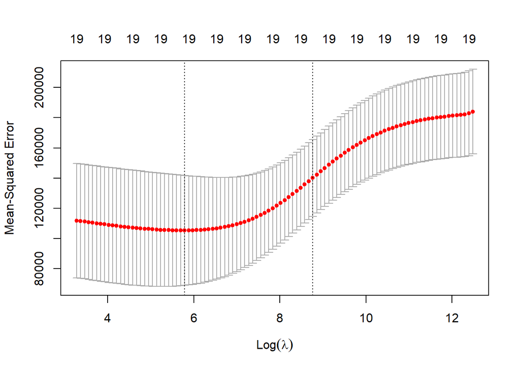

```r
set.seed(1)
cv.out=cv.glmnet(x[train,],y[train],alpha=0)
plot(cv.out)
```

```r
bestlam<-cv.out$lambda.min
bestlam #326.0828
[1] 326.0828
ridge.pred<-predict(ridge.mod,s=bestlam,newx = x[test,])
mean((ridge.pred-y.test)^2) # 139856.6
[1] 139856.6
```

Our new test MSE is 139,856.6 and our ideal lamda is 326.0828